# A tutorial to run diffdriver

# Environmental requirement

Need 16G memory to run diffdriver. The place that needs the most memory is the parameter estimation for background mutation rate model.

# Prepare input

Diffdriver requires three datasets from the user: phenotype or context of each individual tumor sample, somatic mutations identified from tumor samples and a list of driver gene names. Diffdriver will test the association between the phenotype/context with selection strength of each provided driver gene.

- Phenotype/Context

Diffdriver needs phenotype or context of each individual tumor sample. A data frame should provided, in this data frame the first column is sample ID with column name “SampleID”, the second column is phenotype or context with the phenotype or context name as column name (note no space or in tab in column names are allowed). See an example below:

```r
phenof = system.file("extdata/", "example_phenotypes.txt", package = "diffdriver")
pheno <- read.table(phenof, header = T)
head(pheno)
```

```
#>                       SampleID SmokingCessation
#> 1 TCGA-N5-A4R8-01A-11D-A28R-08        0.5319630
#> 2 TCGA-N5-A4RD-01A-11D-A28R-08        0.0448991
#> 3 TCGA-N5-A4RF-01A-11D-A28R-08       -0.3140750
#> 4 TCGA-N5-A4RJ-01A-11D-A28R-08        0.4229920
#> 5 TCGA-N5-A4RM-01A-11D-A28R-08       -0.2830070
#> 6 TCGA-N5-A4RN-01A-12D-A28R-08        0.7874080
```

- Driver genes

A vector of driver gene names. Diffdriver will test the association for each gene.

```r
genef = system.file("extdata", "example_gene.txt", package = "diffdriver")
gene <- read.table(genef, header = F)
head(gene)
```

```
#>       V1
#> 1   CHD4
#> 2 PIK3CA
```

- Somatic mutations

Diffdriver needs the somatic mutations identified for each tumor samples. Note this should include all somatic mutations identified, not just the ones in selected driver genes. Somatic mutations will be used to estimate background mutation rate and selection strength for selected genes. A data frame should be provided, see below for colnames of this data frame and example mutations.

```r
mutf = system.file("extdata/", "example_mutations.txt", package = "diffdriver")
mut <- read.table(mutf, header = T)
head(mut)
```

```
#>   Chromosome  Position Ref Alt                     SampleID
#> 1         19  55653236   C   T TCGA-N6-A4VE-01A-11D-A28R-08
#> 2         17  65134211   C   T TCGA-NA-A4R1-01A-11D-A28R-08
#> 3         20  30354424   G   T TCGA-N8-A4PM-01A-11D-A28R-08
#> 4          6  18215312   G   C TCGA-N8-A4PO-01A-11D-A28R-08
#> 5          1 154186393   C   G TCGA-NA-A4R0-01A-11D-A28R-08
#> 6         10  23003128   C   A TCGA-NF-A4X2-01A-11D-A28R-08
```

In addition to these datasets provided by the user, diffdriver also needs annotation files. See the package installation page for download links to these annotation files. Unless the number of tumor samples or number of mutations is very small, we suggest to use the 96-annotation files. Please download these files to a folder and provide the folder address to diffdriver.

- Directory that contains annotation files

```r
annodir = "/Volumes/Szhao/library/diffdriver_anno/annodir96"
list.files(annodir)
```

```
#>  [1] "anno96_nttype1_annodata.txt"  "anno96_nttype10_annodata.txt"
#>  [3] "anno96_nttype11_annodata.txt" "anno96_nttype12_annodata.txt"
#>  [5] "anno96_nttype13_annodata.txt" "anno96_nttype14_annodata.txt"
#>  [7] "anno96_nttype15_annodata.txt" "anno96_nttype16_annodata.txt"
#>  [9] "anno96_nttype17_annodata.txt" "anno96_nttype18_annodata.txt"
#> [11] "anno96_nttype19_annodata.txt" "anno96_nttype2_annodata.txt"
#> [13] "anno96_nttype20_annodata.txt" "anno96_nttype21_annodata.txt"
#> [15] "anno96_nttype22_annodata.txt" "anno96_nttype23_annodata.txt"
#> [17] "anno96_nttype24_annodata.txt" "anno96_nttype25_annodata.txt"
#> [19] "anno96_nttype26_annodata.txt" "anno96_nttype27_annodata.txt"
#> [21] "anno96_nttype28_annodata.txt" "anno96_nttype29_annodata.txt"
#> [23] "anno96_nttype3_annodata.txt"  "anno96_nttype30_annodata.txt"
#> [25] "anno96_nttype31_annodata.txt" "anno96_nttype32_annodata.txt"
#> [27] "anno96_nttype33_annodata.txt" "anno96_nttype34_annodata.txt"
#> [29] "anno96_nttype35_annodata.txt" "anno96_nttype36_annodata.txt"
```

[output cut: 33 more lines]

# Run diffdriver

```r
# library(diffdriver)
output_dir <- "/tmp/diffdriver_output"
```

With signature adjustment (`BMRmode = "signature"`), which is the default mode, it will need around 15min to estimate parameters in background model. Please use the provided the annotation folder with 96-annotation files when running with the “signature mode”.

```r
library(diffdriver)
res <- diffdriver(gene = gene, mut= mut, pheno = pheno, anno_dir = "/Volumes/Szhao/library/diffdriver_anno/annodir96", k=6, totalnttype = 96, BMRmode = "signature", output_dir = output_dir, output_prefix = "testdiffdriver_sig")
```

```
#> [1] "Infer parameters in background mutation rate model"
#> [1] "coding..."
#> [1] "processing ..."
#> [1] "for qnvars, filling in missing values ..."
#> [1] "for cvars (0/1 categories), filling in missing values ..."
#> [1] "missing mu and sd"
#> [1] "normalizing categorical variables in annotation matrix ..."
#> Initializing factors using Topic SCORE algorithm.
#> Initializing loadings by running 10 SCD updates.
#> Fitting rank-6 Poisson NMF to 52 x 81 dense matrix.
#> Running at most 100 EM updates, without extrapolation (fastTopics 0.6-192).
#> Refining model fit.
#> Fitting rank-6 Poisson NMF to 52 x 81 dense matrix.
#> Running at most 100 SCD updates, with extrapolation (fastTopics 0.6-192).
#> [1] "Start to prepare input data for target genes ..."
#> [1] "coding..."
#> [1] "processing ..."
#> [1] "for qnvars, filling in missing values ..."
#> [1] "for cvars (0/1 categories), filling in missing values ..."
#> [1] "normalizing categorical variables in annotation matrix ..."
#> [1] "Only keeping the first two columns of the phenotype data frame."
#> [1] "phenotype name is SmokingCessation"
#> [1] "number of samples shared in phenotype and mutation file: 40"
#> [1] "Start to process gene: CHD4"
#> [1] "Start to process gene: PIK3CA"
#> [1] "Finished."
```

```r
res
```

```
#>              dd.p      mlr.p   mlr.v2.p  fisher.p  binom.p      lr.p    dd.fdr
#> CHD4   1.00000000 0.85864512 0.83477953 1.0000000 1.000000 0.7509494 1.0000000
#> PIK3CA 0.05397616 0.01370322 0.01300004 0.5576717 0.453489 0.1443223 0.1079523
#>           mlr.fdr mlr.v2.fdr fisher.fdr binom.fdr    lr.fdr mut.E1 mut.E0 E1 E0
#> CHD4   0.85864512 0.83477953          1 1.0000000 0.7509494      5      4 22 18
#> PIK3CA 0.02740643 0.02600007          1 0.9069781 0.2886446      7      9 22 18
```

Without signature adjustment (`BMRmode = "regular"`), it will need around 15min to estimate parameters in background model. You can use the provided the annotation folder with 9-annotation files or 96-annotation files. The example below uses 96-annotation files. When total number of mutations is low, one should use 9-annotation files.

```r
res <- diffdriver(gene = gene, mut= mut, pheno = pheno,  anno_dir = "/Volumes/Szhao/library/diffdriver_anno/annodir96", totalnttype = 96, BMRmode = "regular", output_dir = output_dir, output_prefix = "testdiffdriver_reg")
```

```
#> [1] "Infer parameters in background mutation rate model"
#> [1] "coding..."
#> [1] "processing ..."
#> [1] "for qnvars, filling in missing values ..."
#> [1] "for cvars (0/1 categories), filling in missing values ..."
#> [1] "missing mu and sd"
#> [1] "normalizing categorical variables in annotation matrix ..."
#> [1] "Start to prepare input data for target genes ..."
#> [1] "coding..."
#> [1] "processing ..."
#> [1] "for qnvars, filling in missing values ..."
#> [1] "for cvars (0/1 categories), filling in missing values ..."
#> [1] "normalizing categorical variables in annotation matrix ..."
#> [1] "Only keeping the first two columns of the phenotype data frame."
#> [1] "phenotype name is SmokingCessation"
#> [1] "number of samples shared in phenotype and mutation file: 40"
#> [1] "Start to process gene: CHD4"
#> [1] "Start to process gene: PIK3CA"
#> [1] "Finished."
```

```r
res
```

```
#>              dd.p      mlr.p   mlr.v2.p  fisher.p  binom.p      lr.p    dd.fdr
#> CHD4   1.00000000 0.85864512 0.83477953 1.0000000 1.000000 0.7509494 1.0000000
#> PIK3CA 0.03021595 0.01370322 0.01300004 0.5576717 0.453489 0.1443223 0.0604319
#>           mlr.fdr mlr.v2.fdr fisher.fdr binom.fdr    lr.fdr mut.E1 mut.E0 E1 E0
#> CHD4   0.85864512 0.83477953          1 1.0000000 0.7509494      5      4 22 18
#> PIK3CA 0.02740643 0.02600007          1 0.9069781 0.2886446      7      9 22 18
```

# Plot specific genes

To visualize the data for specific genes, diffdriver has a plotting function:

```
#> [1] "coding..."
#> [1] "processing ..."
#> [1] "for qnvars, filling in missing values ..."
#> [1] "for cvars (0/1 categories), filling in missing values ..."
#> [1] "normalizing categorical variables in annotation matrix ..."
#> [1] "Only keeping the first two columns of the phenotype data frame."
#> [1] "phenotype name is SmokingCessation"
#> [1] "number of samples shared in phenotype and mutation file: 40"
```

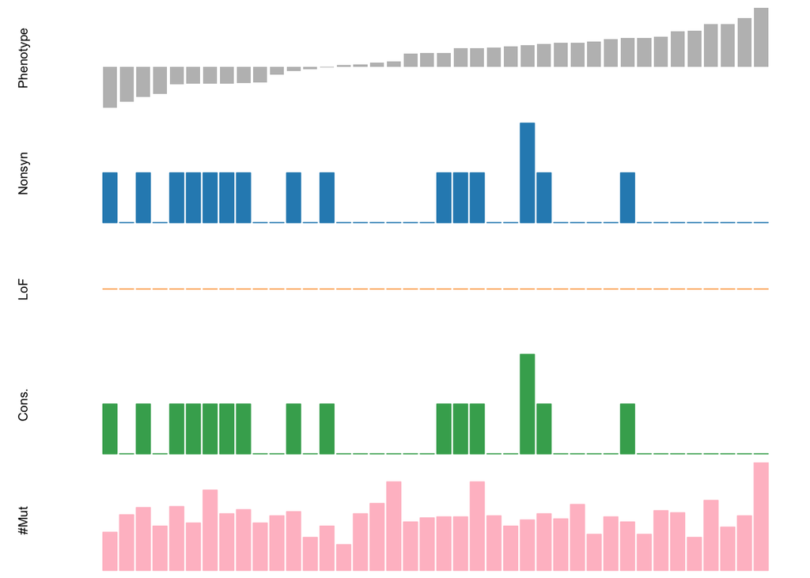

```r
diffdriver::plot_mut(gene_name = "PIK3CA", mut= mut, pheno = pheno, totalnttype = 9, anno_dir = "/Volumes/Szhao/library/diffdriver_anno/annodir9")
```